# University Clustering

#### Performing clustering

```r
set.seed(1234)
k_2 <- kmeans(modeled_data, centers = 2, nstart = 50)
k_4 <- kmeans(modeled_data, centers = 4, nstart = 50)

k_2$size
```

```
## [1] 631 293
```

```r
k_4$size
```

```
## [1]  93 435 319  77
```

```r
#Assign each school to a cluster
school_data <- school_data %>%
  mutate(cluster_2 = k_2$cluster) %>%
  mutate(cluster_4 = k_4$cluster)
```

#### Analyzing results

We can start by simply summarizing each of the resulting groups across our frameworks.

```r
school_data %>%
  select(cluster_2, CONTROL, act_score, pct_admitted, ug_enroll, pct_online, pct_instate, avg_tuition) %>%
  group_by(cluster_2) %>%
  summarize_all('mean')
```

```
## # A tibble: 2 × 8
##   cluster_2 CONTROL act_score pct_admitted ug_enroll pct_online pct_instate
##       <int>   <dbl>     <dbl>        <dbl>     <dbl>      <dbl>       <dbl>
## 1         1    1.39      26.2         79.7     7399.      13.5         80.7
## 2         2    1.89      29.1         61.0     5297.       7.78        35.9
## # ℹ 1 more variable: avg_tuition <dbl>
```

```r
school_data %>%
  select(cluster_4, CONTROL, act_score, pct_admitted, ug_enroll, pct_online, pct_instate, avg_tuition) %>%
  group_by(cluster_4) %>%
  summarize_all('mean')
```

```
## # A tibble: 4 × 8
##   cluster_4 CONTROL act_score pct_admitted ug_enroll pct_online pct_instate
##       <int>   <dbl>     <dbl>        <dbl>     <dbl>      <dbl>       <dbl>
## 1         1    1.96      32.4         34.9     5452.       2.46        24.2
## 2         2    1.30      25.7         81.4     5569.      15.6         85.5
## 3         3    1.89      27.1         76.0     2728.       8.45        51.3
## 4         4    1.03      29.1         68.4    31441.      13.8         73.9
## # ℹ 1 more variable: avg_tuition <dbl>
```

We can also visualize the results. Note that this chart reduces the data into a two-dimensional graph via Principal Component Analysis, which makes the chart much less interpretable… but nonetheless gives a good sense of the rough shapes and overlaps present within our clusters.

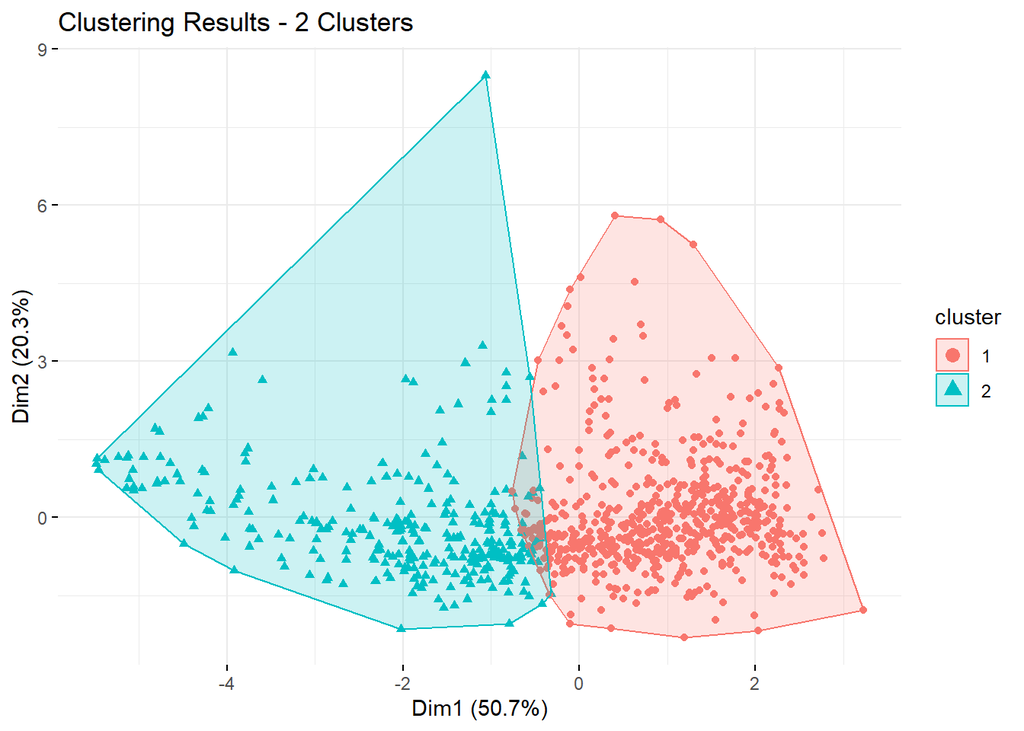

```r
fviz_cluster(k_2,
             data = modeled_data,
             repel = TRUE,
             geom = "point",
             ggtheme = theme_minimal(),
             title = "Clustering Results - 2 Clusters")
```

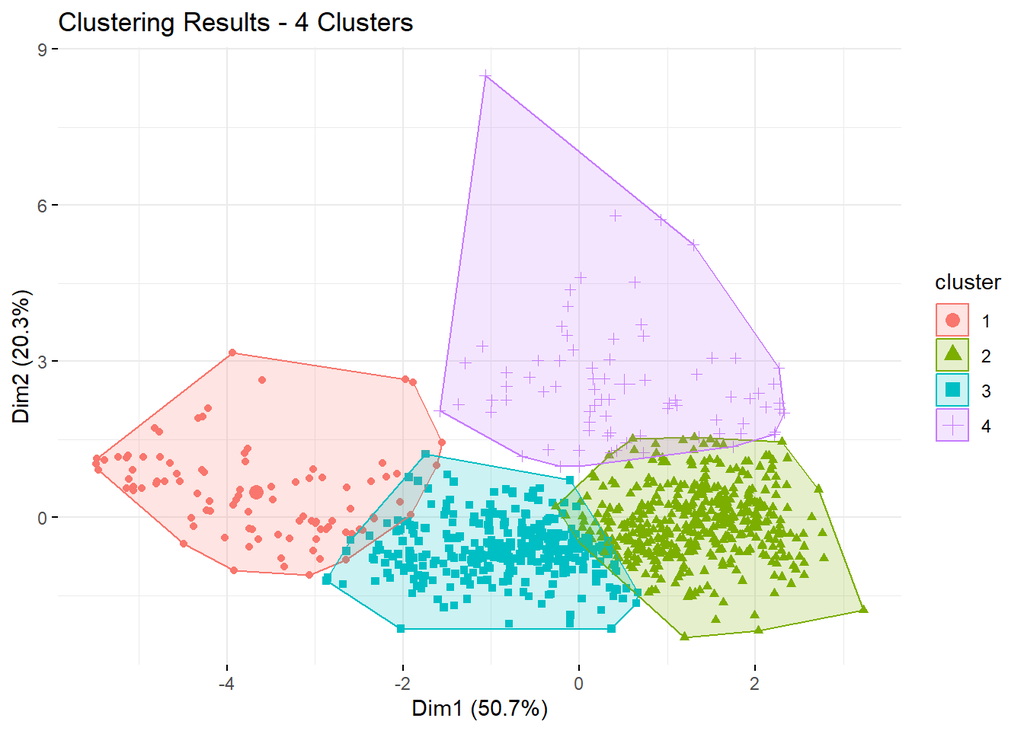

```r
fviz_cluster(k_4,
             data = modeled_data,
             repel = TRUE,
             geom = "point",
             ggtheme = theme_minimal(),
             title = "Clustering Results - 4 Clusters")
```

To me, two groups doesn’t seem descriptive enough, so sticking with 4 groups feels right.

Let’s see the summary table on the four-group split again.

```r
library(kableExtra)
school_data %>%
  select(cluster_4, CONTROL, act_score, pct_admitted, ug_enroll, pct_online, pct_instate, avg_tuition) %>%
  group_by(cluster_4) %>%
  summarize_all('mean') %>%
  kable(digits=2, format = 'markdown',row.names = TRUE) %>%
  kable_styling(full_width = T,
                font_size = 12) %>%
  row_spec(row = 0, color = '#660033')
```

|  | cluster_4 | CONTROL | act_score | pct_admitted | ug_enroll | pct_online | pct_instate | avg_tuition |
| --- | --- | --- | --- | --- | --- | --- | --- | --- |
| 1 | 1 | 1.96 | 32.36 | 34.90 | 5451.74 | 2.46 | 24.15 | 52479.63 |
| 2 | 2 | 1.30 | 25.71 | 81.37 | 5569.05 | 15.64 | 85.48 | 13954.39 |
| 3 | 3 | 1.89 | 27.10 | 76.01 | 2728.06 | 8.45 | 51.29 | 32747.36 |
| 4 | 4 | 1.03 | 29.09 | 68.35 | 31440.71 | 13.84 | 73.88 | 13146.53 |